# Week 12 - In-Class Exercise

STA 235H - Fall 2023

# Setup

In this exercise, we will be working with the same data as before!

You work at a marketing firm, and are trying to predict characteristics for different segments of your audience (customers from a car insurance company). You have the following dataset that will help you build your model:

```r
library(tidyverse)
library(caret)
library(modelr)

# You will need to install these two packages:
library(rpart)
library(rattle)

marketing = read.csv("https://raw.githubusercontent.com/maibennett/sta235/main/exampleSite/content/Classes/Week10/1_ModelSelection/data/marketing.csv")

# For simplicity, we will drop some variables, but you can use them all afterward if you want!
marketing = marketing %>% select(Customer, Customer.Lifetime.Value, Response, Coverage, Education, EmploymentStatus,
                                  Gender, Income, Location.Code, Marital.Status, Monthly.Premium.Auto,
                                  Months.Since.Last.Claim, Number.of.Policies,
                                  Policy.Type, Sales.Channel, Total.Claim.Amount, Renew.Offer.Type)
```

Here’s the list of some variables in your dataset:

- `Customer`: Customer ID (*Note: ID variables are usually not predictors!*)
- `Customer.Lifetime.Value`: Estimate of the value of a customer (*In this example, this is what we will predict*)
- `Response`: Whether the client took the offer or not
- `Coverage`: Type of insurance coverage
- `Education`, `Gender`, `Income`, `Location.Code`, `Marital.Status`: Client’s characteristics.
- `Renew.Offer.Type`: Offer made to the client (out of four different options)
- `Response`: Whether a customer responds to an offer or not.

Continuing with the task we were doing last week, run the following code and start from there:

```r
marketing = marketing %>% select(-Customer) %>% mutate(Response = ifelse(Response=="No", 0, 1))

marketing = marketing %>% mutate_if(is.character, as.factor)

set.seed(100) #Remember always to set seed before something random (in this case, sample())

n = nrow(marketing) #Number of obs in our marketing dataset

train = sample(1:n, nrow(marketing)*0.75) #Row numbers for 75% of our data (randomly selected)

train.data = marketing %>% slice(train)
test.data = marketing %>% slice(-train)
```

## Tasks

1. We are going to fit a regression tree to find the predicted values for Customer Lifetime Value. Using all the predictors in your dataset (except for `Response`), fit a regression tree. Start using `tuneLength = 20` to find the best neighborhood for your complexity parameter `cp` (plot your complexity parameter), and then use the argument `tuneGrid` to find the best model that you can. Use a 5-fold CV approach, and use a `set.seed(100)`.

**Q5: What is the best `cp` in this case?**

**Q6: What is the variable that is most predictive in your tree?**

**Q7: How does your model perform? Use an appropriate measure.**

*Answer:*

Starting with `tuneLength=20`, we can see that the best RMSE is probably around 0.01

```r
set.seed(100)

rt = train(
  Customer.Lifetime.Value ~ . - Response, data = train.data,
  method = "rpart",
  trControl = trainControl("cv", number = 5),
  tuneLength = 20
  )
```

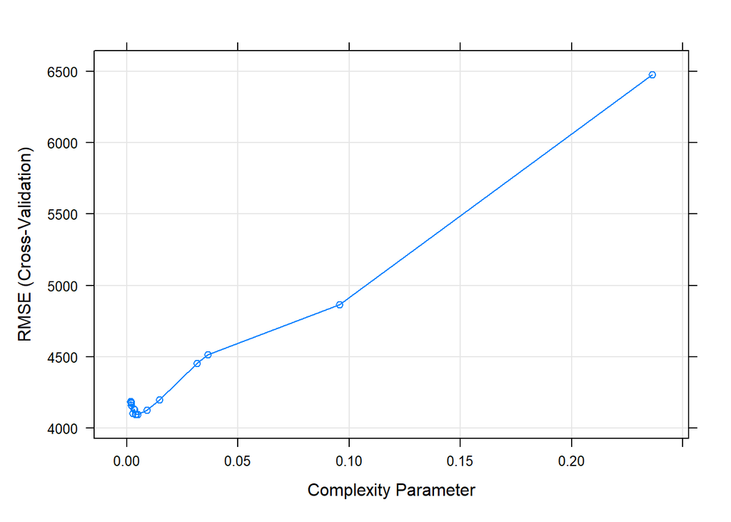

```r
plot(rt)
```

Let’s now use `tuneGrid` to get a better plot:

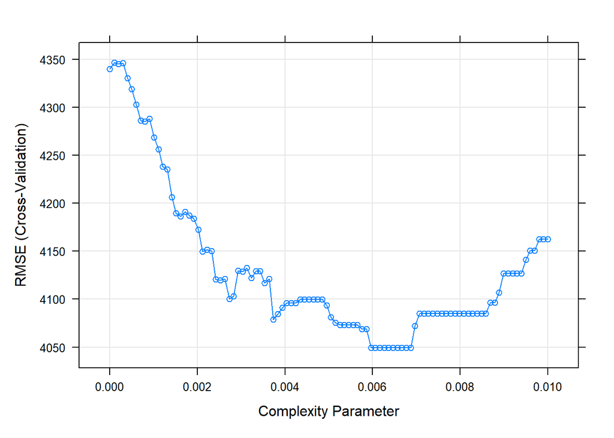

```r
set.seed(100)

rt = train(
  Customer.Lifetime.Value ~ . - Response, data = train.data,
  method = "rpart",
  trControl = trainControl("cv", number = 5),
  tuneGrid = expand.grid(cp = seq(0, 0.01, length = 100)) # You can use "length" or "by"
  )

plot(rt)
```

Once we are happy with our results, we can get our optimal `cp` using `rt$bestTune`:

```r
rt$bestTune
```

|  | cp |
| --- | --- |
| 69 | 0.0068687 |

We can also plot our tree:

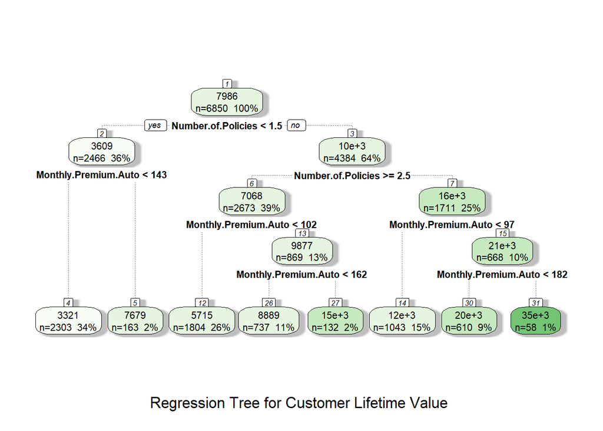

```r
fancyRpartPlot(rt$finalModel, caption = "Regression Tree for Customer Lifetime Value")
```

And in our case, `Number.of.Policies` is the most predictive variable (top of the tree). You can also use `rt$finalModel` if you are not able to see the tree plot very clearly.

And finally, let’s calculate our RMSE:

```r
rmse(rt, test.data)
```

```
## [1] 4064.372
```

2. Now, we are going to predict the Response variable (you can use all predictors now, including Customer Lifetime Value). Fit a regression tree, starting with `tuneLength = 50` to find the best neighborhood for your complexity parameter `cp` (plot your complexity parameter), and then use the argument `tuneGrid` to find the best model that you can. Use a 5-fold CV approach, and use a `set.seed(100)`. What is the best complexity parameter in this case? How does your model perform?

*Answer:*

We start with `tuneLength = 50` and can clearly see that the best `cp` is closer to 0, so we will focus on that neighborhood.

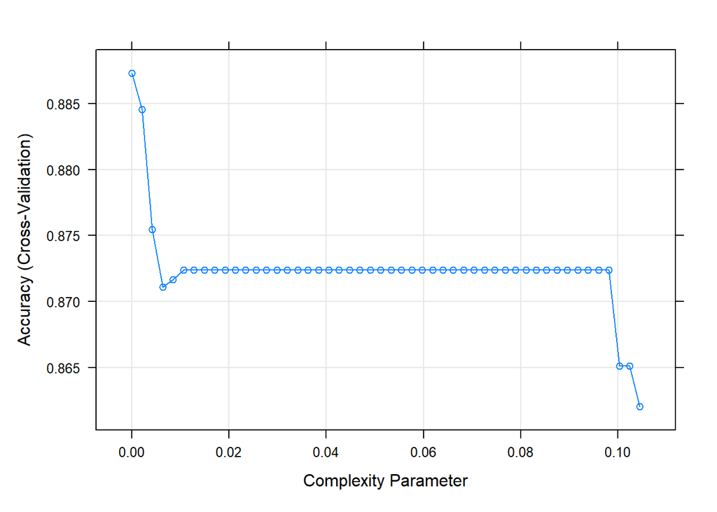

```r
set.seed(100)

ct = train(
  factor(Response) ~ ., data = train.data,
  method = "rpart",
  trControl = trainControl("cv", number = 5),
  tuneLength = 50
  )

plot(ct)
```

We look between 0 and 0.01 for the best `cp` in this case:

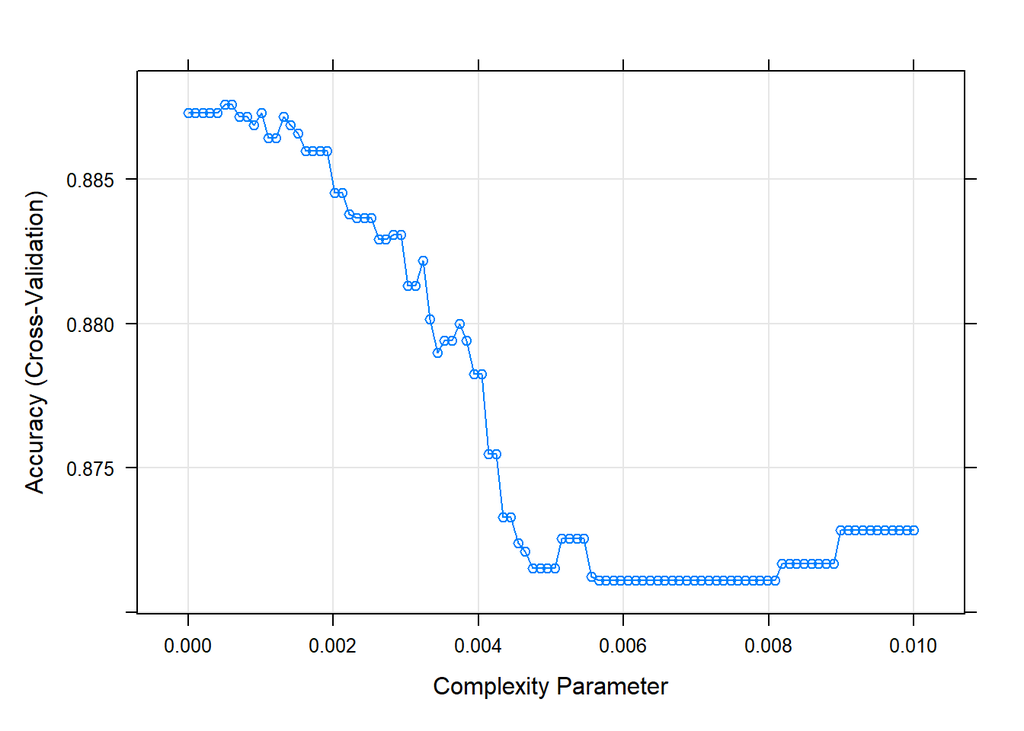

```r
set.seed(100)

ct = train(
  factor(Response) ~ ., data = train.data,
  method = "rpart",
  trControl = trainControl("cv", number = 5),
  tuneGrid = expand.grid(cp = seq(0, 0.01, length = 100))
  )

plot(ct)
```

```r
ct$bestTune
```

|  | cp |
| --- | --- |
| 7 | 0.0006061 |

```r
pred.values = ct %>% predict(test.data)

mean(pred.values == test.data$Response)
```

```
## [1] 0.9102452
```

Our best `cp` is 6.0606061^{-4} and our accuracy is 91.02%